# GAN to generate apple or pencil according to the feeded data

This GAN model is trained to generate apple or pencil image according to the input data given by user.

Since the processing of colored images takes a lot of time, this model is trained using **Hand drawn figure dataset** from **Google Draw**. This is a basic version which will be extended further to colorful original images.

```python
import pandas as pd
import numpy as np
```

```python
data_apple = np.load("../input/full_numpy_bitmap_apple.npy")
data_pencil = np.load("../input/full_numpy_bitmap_pencil.npy")
```

```python
import keras
from keras.layers import *
from keras.callbacks import *
from keras.models import *
from keras.losses import *
from keras.optimizers import *
import matplotlib.pyplot as plt
import seaborn as sns
import glob
```

## Generator

The following generator model is similar to CNN. It takes two input : latent_input | size - 100 | takes random values label_input | size - 1 | takes value {0, 1}

The output of this model is a 28x28 matrix which actually corresponds to the generated images whose dimension are 28x28 pixels.

```python
latent_input = Input(shape=(100,), name='latent_input')
label_input = Input(shape=(1,), name='label_input')
x = Embedding(input_dim=2, output_dim=2)(label_input)
x = Reshape((2,))(x)
x = concatenate([x, latent_input], axis=-1)
x = Dense(7*7*128)(x)
x = LeakyReLU()(x)
x = Reshape((7,7,128))(x)
x = UpSampling2D()(x)
x = Conv2D(64, kernel_size=3, strides=1, padding='same')(x)
x = LeakyReLU()(x)
x = BatchNormalization()(x)
x = UpSampling2D()(x)
x = Conv2D(32, kernel_size=3, strides=1, padding='same')(x)
x = LeakyReLU()(x)
x = BatchNormalization()(x)
x = Conv2D(1, kernel_size=3, strides=1, padding='same')(x)
x = Activation('sigmoid')(x)
x = Reshape((28,28,))(x)
generator = Model(inputs=[latent_input, label_input], outputs=x)
generator.summary()
```

```
__________________________________________________________________________________________________
Layer (type)                    Output Shape         Param #     Connected to
==================================================================================================
label_input (InputLayer)        (None, 1)            0
__________________________________________________________________________________________________
embedding_1 (Embedding)         (None, 1, 2)         4           label_input[0][0]
__________________________________________________________________________________________________
reshape_1 (Reshape)             (None, 2)            0           embedding_1[0][0]
__________________________________________________________________________________________________
latent_input (InputLayer)       (None, 100)          0
__________________________________________________________________________________________________
concatenate_1 (Concatenate)     (None, 102)          0           reshape_1[0][0]
                                                                 latent_input[0][0]
__________________________________________________________________________________________________
dense_1 (Dense)                 (None, 6272)         646016      concatenate_1[0][0]
__________________________________________________________________________________________________
leaky_re_lu_1 (LeakyReLU)       (None, 6272)         0           dense_1[0][0]
__________________________________________________________________________________________________
reshape_2 (Reshape)             (None, 7, 7, 128)    0           leaky_re_lu_1[0][0]
__________________________________________________________________________________________________
up_sampling2d_1 (UpSampling2D)  (None, 14, 14, 128)  0           reshape_2[0][0]
__________________________________________________________________________________________________
conv2d_1 (Conv2D)               (None, 14, 14, 64)   73792       up_sampling2d_1[0][0]
__________________________________________________________________________________________________
leaky_re_lu_2 (LeakyReLU)       (None, 14, 14, 64)   0           conv2d_1[0][0]
__________________________________________________________________________________________________
batch_normalization_1 (BatchNor (None, 14, 14, 64)   256         leaky_re_lu_2[0][0]
__________________________________________________________________________________________________
up_sampling2d_2 (UpSampling2D)  (None, 28, 28, 64)   0           batch_normalization_1[0][0]
__________________________________________________________________________________________________
conv2d_2 (Conv2D)               (None, 28, 28, 32)   18464       up_sampling2d_2[0][0]
__________________________________________________________________________________________________
leaky_re_lu_3 (LeakyReLU)       (None, 28, 28, 32)   0           conv2d_2[0][0]
__________________________________________________________________________________________________
batch_normalization_2 (BatchNor (None, 28, 28, 32)   128         leaky_re_lu_3[0][0]
__________________________________________________________________________________________________
conv2d_3 (Conv2D)               (None, 28, 28, 1)    289         batch_normalization_2[0][0]
__________________________________________________________________________________________________
activation_1 (Activation)       (None, 28, 28, 1)    0           conv2d_3[0][0]
__________________________________________________________________________________________________
reshape_3 (Reshape)             (None, 28, 28)       0           activation_1[0][0]
==================================================================================================
Total params: 738,949
Trainable params: 738,757
Non-trainable params: 192
__________________________________________________________________________________________________
```

## Discriminator

This discriminator takes images as input and predicts its label. This is a CNN.

```python
img_input = Input(shape=(28,28,))
x = Reshape((28,28,1))(img_input)
x = Conv2D(16, kernel_size=3, strides=2, padding='same')(x)
x = LeakyReLU()(x)
x = BatchNormalization()(x)
x = Conv2D(32, kernel_size=3, strides=2, padding='same')(x)
x = LeakyReLU()(x)
x = BatchNormalization()(x)
x = Conv2D(64, kernel_size=3, strides=2, padding='same')(x)
x = LeakyReLU()(x)
x = BatchNormalization()(x)
x = Conv2D(128, kernel_size=3, strides=2, padding='same')(x)
x = LeakyReLU()(x)
x = Dropout(0.3)(x)
x = BatchNormalization()(x)
x = Flatten()(x)
x = Dense(11, activation='softmax')(x)
discriminator = Model(inputs=img_input, outputs=x)
discriminator.summary()
```

```
_________________________________________________________________
Layer (type)                 Output Shape              Param #
=================================================================
input_1 (InputLayer)         (None, 28, 28)            0
_________________________________________________________________
reshape_4 (Reshape)          (None, 28, 28, 1)         0
_________________________________________________________________
conv2d_4 (Conv2D)            (None, 14, 14, 16)        160
_________________________________________________________________
leaky_re_lu_4 (LeakyReLU)    (None, 14, 14, 16)        0
_________________________________________________________________
batch_normalization_3 (Batch (None, 14, 14, 16)        64
_________________________________________________________________
conv2d_5 (Conv2D)            (None, 7, 7, 32)          4640
_________________________________________________________________
leaky_re_lu_5 (LeakyReLU)    (None, 7, 7, 32)          0
_________________________________________________________________
batch_normalization_4 (Batch (None, 7, 7, 32)          128
_________________________________________________________________
conv2d_6 (Conv2D)            (None, 4, 4, 64)          18496
_________________________________________________________________
leaky_re_lu_6 (LeakyReLU)    (None, 4, 4, 64)          0
_________________________________________________________________
batch_normalization_5 (Batch (None, 4, 4, 64)          256
_________________________________________________________________
conv2d_7 (Conv2D)            (None, 2, 2, 128)         73856
_________________________________________________________________
leaky_re_lu_7 (LeakyReLU)    (None, 2, 2, 128)         0
_________________________________________________________________
dropout_1 (Dropout)          (None, 2, 2, 128)         0
_________________________________________________________________
batch_normalization_6 (Batch (None, 2, 2, 128)         512
_________________________________________________________________
flatten_1 (Flatten)          (None, 512)               0
_________________________________________________________________
dense_2 (Dense)              (None, 11)                5643
=================================================================
Total params: 103,755
Trainable params: 103,275
Non-trainable params: 480
_________________________________________________________________
```

### GAN model

There are three models.

1. Generator
2. Dicriminator
3. GAN - It is actually [Generator + Discriminator] appended model

## Note

While training this GAN, these are the steps that we follow.

1. Make the discriminator trainable (If we make trainable = False, the weights gets fixed)
2. Train the discriminator using the actual datasets(y as corresponding label) and the generated image from generator (y as some different label corresponding to fake image)
3. Make the discriminator non-trainable. Now the weights in discriminator are fixed.( Note that this discriminator is also appended in GAN model)
4. Train the GAN with latent_input and label_input(described above) corresponding the label_input as y. This forces the generator to generate images which gives corresponding y as output by modifying the weights.

ITERATE THROUGH THE ABOVE STEPS

```python
latent_input = Input(shape=(100,), name='latent_input')
label_input = Input(shape=(1,), name='label_input')
x = generator([latent_input, label_input])
x = discriminator(x)
gan = Model(inputs=[latent_input, label_input], outputs=x)
discriminator.trainable = False
gan.summary()
```

```
__________________________________________________________________________________________________
Layer (type)                    Output Shape         Param #     Connected to
==================================================================================================
latent_input (InputLayer)       (None, 100)          0
__________________________________________________________________________________________________
label_input (InputLayer)        (None, 1)            0
__________________________________________________________________________________________________
model_1 (Model)                 (None, 28, 28)       738949      latent_input[0][0]
                                                                 label_input[0][0]
__________________________________________________________________________________________________
model_2 (Model)                 (None, 11)           103755      model_1[1][0]
==================================================================================================
Total params: 842,704
Trainable params: 738,757
Non-trainable params: 103,947
__________________________________________________________________________________________________
```

```python
discriminator.trainable = True
discriminator.compile(loss='sparse_categorical_crossentropy', metrics=['acc'], optimizer=Adam(0.001))
discriminator.trainable = False
gan.compile(loss='sparse_categorical_crossentropy', metrics=['acc'], optimizer=Adam(0.0003))
```

```python
def random_mnist_set(X, y, size=2):
    length = len(X)
    indices = np.random.choice(length, size)
    return X[indices], y[indices]

def random_generated_set(generator, size=2):
    latents = np.random.normal(0, 1, (size, 100))
    return generator.predict_on_batch({'latent_input':latents,
                      'label_input':np.random.randint(2, size=size)})
```

```python
data_apple = data_apple.reshape(-1,28,28)/255
data_pencil = data_pencil.reshape(-1,28,28)/255
data_apple = data_apple.tolist()
data_pencil = data_pencil.tolist()
```

```python
print("apple length : ", len(data_apple))
label_apple = [0]*len(data_apple)
label_pencil = [1]*len(data_pencil)
data_apple.extend(data_pencil)
label_apple.extend(label_pencil)
print("net list lenght", len(data_apple))
c = list(zip(data_apple, label_apple))
import random
random.shuffle(c)

X, y = zip(*c)
```

```
apple length :  144722
net list lenght 266723
```

```python
x = np.array(X)
y = np.array(y)
```

### PLOT AND CHECK THE SHUFFLED DATASET

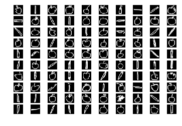

```python
import matplotlib.pyplot as plt

for i in range(100):
    plt.subplot(10,10,i+1)
    plt.imshow(x[i], cmap='gray')
    plt.axis('off')
```

```python
y[:100]
```

```
array([0, 1, 0, 0, 0, 0, 1, 1, 1, 0, 1, 0, 1, 1, 0, 0, 1, 0, 0, 0, 1, 0,
       0, 0, 1, 0, 1, 0, 1, 1, 0, 0, 1, 0, 0, 0, 0, 0, 1, 0, 1, 1, 0, 0,
       0, 0, 0, 0, 1, 1, 1, 0, 1, 1, 1, 0, 0, 1, 1, 1, 0, 1, 0, 1, 0, 1,
       1, 1, 0, 0, 0, 0, 1, 1, 0, 1, 0, 1, 0, 0, 1, 1, 0, 0, 0, 0, 1, 0,
       1, 0, 1, 1, 1, 1, 1, 0, 0, 1, 0, 1])
```

## MAIN TRAINING CODE

```python
save_interval = 300
epochs = save_interval*10+1
batch_size=20
history = {'dloss':[], 'gloss':[]}
for iteration in range(epochs):
    discriminator.trainable=True
    X_sample, y_sample = random_mnist_set(x, y, batch_size)
    dloss_real = discriminator.train_on_batch(X_sample, y_sample)
    dloss_fake = discriminator.train_on_batch(random_generated_set(generator, size=batch_size), np.full(batch_size, 2))

    discriminator.trainable=False

    gan_labels = np.random.randint(2, size=batch_size)
    gloss = gan.train_on_batch({'latent_input':np.random.normal(0, 1, (batch_size, 100)),
                        'label_input':gan_labels},
                       gan_labels)

    history['dloss'].append((dloss_real[0]+dloss_fake[0])/2)
    history['gloss'].append(gloss[0])
    if iteration % save_interval == 0:
        print('generator: loss={}. acc={}'.format(gloss[0], gloss[1]))
        print('discriminator: loss_real={}, acc_real={}'.format(dloss_real[0],dloss_real[1]))
        print('    loss_fake={}, acc_fake={}'.format(dloss_fake[0],dloss_fake[1]))
        generator.save_weights('generator_{0:05d}.h5'.format(iteration))
```

```
generator: loss=2.951396942138672. acc=0.15000000596046448
discriminator: loss_real=3.37095308303833, acc_real=0.0
    loss_fake=3.6842262744903564, acc_fake=0.0
generator: loss=12.602798461914062. acc=0.0
discriminator: loss_real=0.10284280776977539, acc_real=0.949999988079071
    loss_fake=0.07603689283132553, acc_fake=0.949999988079071
generator: loss=7.74118185043335. acc=0.0
discriminator: loss_real=0.00519949896261096, acc_real=1.0
    loss_fake=0.0007885033264756203, acc_fake=1.0
generator: loss=4.886561870574951. acc=0.05000000074505806
discriminator: loss_real=0.08874578028917313, acc_real=1.0
    loss_fake=0.0004041685606352985, acc_fake=1.0
generator: loss=8.501688957214355. acc=0.0
discriminator: loss_real=0.10759349912405014, acc_real=0.949999988079071
    loss_fake=0.0045493608340620995, acc_fake=1.0
generator: loss=6.894505500793457. acc=0.0
discriminator: loss_real=1.1165955066680908, acc_real=0.44999998807907104
    loss_fake=0.041579391807317734, acc_fake=1.0
generator: loss=4.140135765075684. acc=0.0
discriminator: loss_real=0.01080915704369545, acc_real=1.0
    loss_fake=0.1386798918247223, acc_fake=0.949999988079071
generator: loss=7.973807334899902. acc=0.0
discriminator: loss_real=0.014030402526259422, acc_real=1.0
    loss_fake=0.029022585600614548, acc_fake=1.0
generator: loss=2.311023712158203. acc=0.20000000298023224
discriminator: loss_real=0.06460103392601013, acc_real=0.949999988079071
    loss_fake=0.07068560272455215, acc_fake=1.0
generator: loss=5.3698320388793945. acc=0.0
discriminator: loss_real=0.024008627980947495, acc_real=1.0
    loss_fake=0.17541451752185822, acc_fake=0.949999988079071
generator: loss=6.467932224273682. acc=0.0
discriminator: loss_real=0.1829795390367508, acc_real=0.949999988079071
    loss_fake=0.020452257245779037, acc_fake=1.0
```

### Generated images of Apple and Pencil during the training.

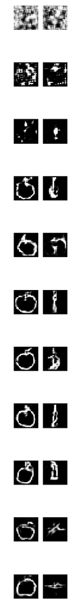

```python
checkpoints = sorted(glob.glob('generator_*.h5'))

plt.figure(figsize=(10,2*len(checkpoints)))
for i,cp in enumerate(checkpoints):
    generator.load_weights(cp)
    generated = generator.predict_on_batch({'latent_input':np.random.normal(0, 1, (2, 100)),
                      'label_input':np.arange(2)})
    for j, g in enumerate(generated):
        plt.subplot(len(checkpoints),10,10*i+j+1)
        plt.imshow(g, cmap='gray')
        plt.axis('off')
```

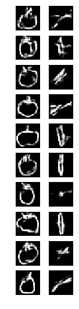

```python
generator.load_weights(checkpoints[-1])
plt.figure(figsize=(10,10))
for i in range(10):
    generated = generator.predict_on_batch({'latent_input':np.random.normal(0, 1, (2, 100)),
                      'label_input':np.arange(2)})
    for j, g in enumerate(generated):
        plt.subplot(len(checkpoints),10,10*i+j+1)
        plt.imshow(g, cmap='gray')
        plt.axis('off')
```